# Analyse de l’impact de la température sur la consommation d’électricité

Cas d’étude: La Tunisie entre 2015 et 2022

Manel Garmachi

2025-12-30

# 1 Contexte et objectifs clairs

## 1.1 Contexte

La Tunisie connaît une augmentation continue de la demande en électricité, portée par le développement économique, l’urbanisation et l’évolution des modes de consommation.  
Parallèlement, le pays est soumis à des variations climatiques marquées, notamment des vagues de chaleur estivales, susceptibles d’accentuer la consommation liée à la climatisation.  
Dans ce contexte, analyser le lien entre la température et la consommation d’électricité est essentiel pour mieux comprendre la dynamique de la demande énergétique et aider à la planification du système électrique.

## 1.2 Problématique

Dans quelle mesure les variations de température influencent-elles la consommation d’électricité en Tunisie  
sur la période 2015–2022 ?

## 1.3 Objectifs

### 1.3.1 Objectif principal

L’objectif principal de ce projet est d’analyser l’impact des variations de température sur la consommation d’électricité en Tunisie entre 2015 et 2022, en utilisant des données ouvertes et des outils de data science sous R.

### 1.3.2 Objectifs spécifiques

- Collecter et préparer deux sources de données pour la période 2015–2022 :
  - la consommation d’électricité par habitant (kWh per capita) issue de la Banque mondiale (fichier CSV)
  - les températures historiques à Tunis obtenues par web scraping à partir d’un site météo.
- Construire un jeu de données consolidé liant, pour chaque année entre 2015 et 2022, la consommation d’électricité et la température moyenne.
- Réaliser une analyse exploratoire des tendances de la consommation d’électricité et de la température sur la période étudiée.
- Modéliser la relation entre les deux variables principales (consommation d’électricité et température moyenne) à l’aide de modèles de régression sous R.
- Interpréter les résultats obtenus et discuter leurs implications pour la gestion de la demande énergétique en Tunisie.

## 1.4 Spécification des Variables

### 1.4.1 Variable dépendante : Consommation d’électricité

La variable dépendante de cette étude est la consommation d’électricité par habitant en Tunisie, mesurée par l’indicateur *Electric power consumption (kWh per capita)* fourni par la Banque mondiale. Les données annuelles sont extraites sous forme de fichier CSV puis filtrées pour la période 2015–2022. Chaque valeur représente la quantité moyenne d’électricité consommée par habitant au cours d’une année donnée.

### 1.4.2 Variable explicative : Température moyenne

La variable explicative principale est la température moyenne annuelle, obtenue à partir de données météorologiques historiques pour la ville de Tunis recueillies par web scraping depuis un site de météo.

Les données journalières ou mensuelles sont d’abord extraites au format tableau (HTML), puis agrégées pour calculer, pour chaque année de 2015 à 2022, une température moyenne annuelle.

Cette température moyenne est ensuite utilisée pour expliquer la variation de la consommation d’électricité.

## 1.5 Période d’étude

L’analyse est menée sur la période 2015–2022, ce qui permet de disposer d’un horizon temporel récent tout en tenant compte de plusieurs années de variations climatiques et de consommation.

## 1.6 Modélisation à deux variables

La relation entre la consommation d’électricité par habitant et la température moyenne annuelle est étudiée à l’aide de modèles de régression sous R.

Dans un premier temps, un modèle de régression linéaire simple est estimé, où la consommation d’électricité constitue la variable dépendante et la température moyenne la variable explicative.

Des modèles éventuellement non linéaires (par exemple avec un terme quadratique en température) peuvent également être testés afin de mieux capturer l’effet de la température sur la consommation.

## 1.7 Sources de données

Cette étude repose sur deux principales sources de données.

### 1.7.1 Consommation d’électricité

La première source concerne la consommation d’électricité par habitant en Tunisie. Les données sont issues de la base de données de la **Banque mondiale**, à travers l’indicateur *Electric power consumption (kWh per capita)*.  
Les données sont téléchargées au format **CSV**, puis filtrées afin de conserver uniquement la période allant de **2015 à 2022**.

### 1.7.2 Température

La deuxième source concerne la température. Les données de température historique pour la ville de **Tunis** sont collectées à partir d’un site de météo en ligne.  
Elles sont extraites par **web scraping sous R**, à l’aide du package **rvest**. Les données recueillies sont ensuite agrégées afin de calculer une **température moyenne annuelle** pour chaque année comprise entre **2015 et 2022**.

## 1.8 Importation des données

Au début de notre analyse, nous commençons par intégrer les données essentielles à partir des sources distincts.

```r
# Charger le package tidyverse (manipulation et nettoyage des données)
library(tidyverse)

# Lire le fichier CSV de la Banque mondiale
# skip = 4 permet d’ignorer les premières lignes non utiles du fichier
wb_raw <- read.csv("API_EG.USE.ELEC.KH.PC_DS2_en_csv_v2_1880.csv", skip = 4)

# Filtrer les données pour ne garder que la Tunisie
# Country.Code = "TUN" correspond au code pays de la Tunisie
wb_tunisia <- wb_raw %>%
  filter(Country.Code == "TUN")

# Transformer les colonnes des années en format long
# Les colonnes commencent par "X" (ex : X2015, X2016, ...)
wb_long <- wb_tunisia %>%
  pivot_longer(
    cols = starts_with("X"),           # Sélection des colonnes des années
    names_to = "year",                  # Nom de la nouvelle colonne des années
    values_to = "elec_kwh_per_capita"   # Nom de la colonne de consommation
  ) %>%
  mutate(
    # Supprimer le "X" devant l’année (X2015 → 2015)
    # puis convertir l’année en entier
    year = as.integer(sub("X", "", year))
  )

# Filtrer les données pour la période d’étude : 2015 à 2022
# et garder uniquement les colonnes utiles
wb_2015_2022 <- wb_long %>%
  filter(year >= 2015, year <= 2022) %>%
  select(year, elec_kwh_per_capita)

# Afficher les données sous forme de tableau propre dans le rapport
knitr::kable(
  wb_2015_2022,
  caption = "Consommation d'électricité par habitant en Tunisie (2015–2022)"
)
```

Consommation d’électricité par habitant en Tunisie (2015–2022)

| year | elec_kwh_per_capita |
| --- | --- |
| 2015 | 1438.925 |
| 2016 | 1442.057 |
| 2017 | 1457.534 |
| 2018 | 1464.789 |
| 2019 | 1533.800 |
| 2020 | 1423.244 |
| 2021 | 1519.593 |
| 2022 | 1595.467 |

## 1.9 Collecte des données météorologiques

Nous récupérons les températures historiques de Tunis pour la période 2015–2022 à l’aide de web scraping depuis le site timeanddate.com.

```r
# Fonction pour extraire la température moyenne mensuelle

get_month_temp <- function(year, month) {
url <- paste0(
  "https://www.timeanddate.com/weather/tunisia/tunis/historic?month=",
  month,
  "&year=",
  year
)


page <- read_html(url)

df <- page %>%
html_element("table#wt-his") %>%
html_table(fill = TRUE)

# Renommer les colonnes pour éviter les erreurs

names(df) <- paste0("V", seq_along(df))

df_clean <- df %>%
slice(-1) %>%
select(temp = V3) %>%       # le 3e colonne = Temp
mutate(
temp_f = as.numeric(gsub("[^0-9.-]", "", temp)),
temp_c = (temp_f - 32)/1.8   # convertir °F en °C
)

df_clean %>%
summarise(temp_mean = mean(temp_c, na.rm = TRUE)) %>%
mutate(year = year, month = month)
}

# Exemple pour tester janvier 2018

get_month_temp(2018, 1)
```

```
## # A tibble: 1 × 3
##   temp_mean  year month
##       <dbl> <dbl> <dbl>
## 1      14.7  2018     1
```

```r
# Boucle pour toutes les années et tous les mois

years <- 2015:2022
months <- 1:12

all_temps <- map_df(years, function(y) {
map_df(months, function(m) {
Sys.sleep(1)  # petit délai pour ne pas bloquer le site
get_month_temp(y, m)
})
})

# Calculer la température moyenne annuelle

annual_temps <- all_temps %>%
group_by(year) %>%
summarise(annual_temp_mean = mean(temp_mean, na.rm = TRUE)) %>%
ungroup()

# Afficher le tableau

knitr::kable(annual_temps, caption = "Température annuelle moyenne à Tunis (2015–2022)")
```

Température annuelle moyenne à Tunis (2015–2022)

| year | annual_temp_mean |
| --- | --- |
| 2015 | 17.81672 |
| 2016 | 18.02826 |
| 2017 | 17.46436 |
| 2018 | 19.05563 |
| 2019 | 17.27700 |
| 2020 | 18.30727 |
| 2021 | 18.51469 |
| 2022 | 27.73389 |

```r
 write.csv(annual_temps, "temperature_annuelle_tunis.csv", row.names = FALSE)
```

Ce tableau présente la température annuelle moyenne estimée à Tunis sur la période 2015–2022, obtenue par web scraping à partir des observations horaires du site timeanddate.com.

## 1.10 Analyse de Données

### 1.10.1 Analyse temporelle de la consommation d’électricité par habitant en Tunisie (2015–2022)

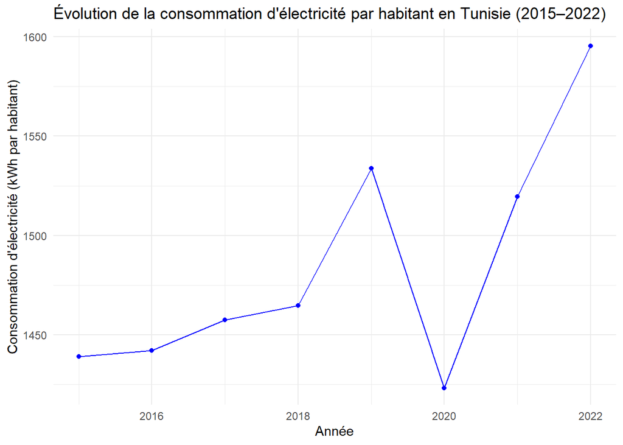

```r
ggplot(wb_2015_2022, aes(x = year, y = elec_kwh_per_capita)) +
geom_line(color = "blue") +
geom_point(color = "blue") +
labs(
title = "Évolution de la consommation d'électricité par habitant en Tunisie (2015–2022)",
x = "Année",
y = "Consommation d'électricité (kWh par habitant)"
) +
theme_minimal()
```

```r
elec_variation <- wb_2015_2022%>%
arrange(year) %>%
mutate(
diff_abs = elec_kwh_per_capita - lag(elec_kwh_per_capita),
diff_pct = 100 * diff_abs / lag(elec_kwh_per_capita)
)

knitr::kable(
elec_variation,
digits = 2,
caption = "Variation annuelle de la consommation d'électricité par habitant en Tunisie (2015–2022)"
)
```

Variation annuelle de la consommation d’électricité par habitant en Tunisie (2015–2022)

| year | elec_kwh_per_capita | diff_abs | diff_pct |
| --- | --- | --- | --- |
| 2015 | 1438.92 | NA | NA |
| 2016 | 1442.06 | 3.13 | 0.22 |
| 2017 | 1457.53 | 15.48 | 1.07 |
| 2018 | 1464.79 | 7.26 | 0.50 |
| 2019 | 1533.80 | 69.01 | 4.71 |
| 2020 | 1423.24 | -110.56 | -7.21 |
| 2021 | 1519.59 | 96.35 | 6.77 |
| 2022 | 1595.47 | 75.87 | 4.99 |

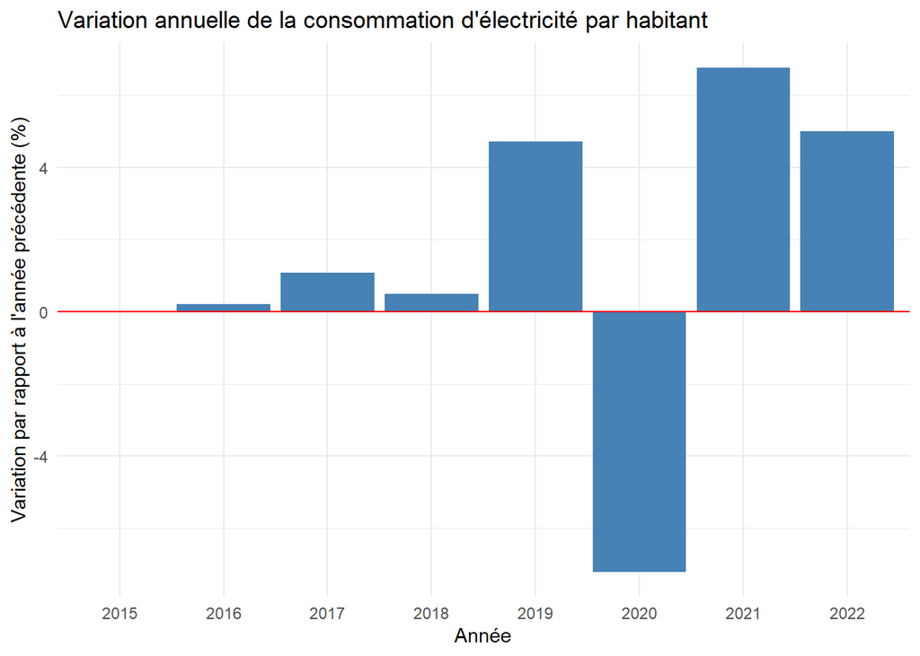

```r
ggplot(elec_variation, aes(x = factor(year), y = diff_pct)) +
geom_col(fill = "steelblue") +
geom_hline(yintercept = 0, color = "red") +
labs(
title = "Variation annuelle de la consommation d'électricité par habitant",
x = "Année",
y = "Variation par rapport à l'année précédente (%)"
) +
theme_minimal()
```